# GISD - German Index of Socio-Economic Deprivation_Revision 2022

Marvin Reis

22 4 2021

## 0. Benötigte Pakete

Der Code nutzt im Wesentlichen die Pakete des Tidyverse, dazu einige Pakete zur Imputation

## I. Generierung eines ID-Datensatzes

Zunächst wird ein Datensatz (ID-Datensatz) generiert in dem den kleinsten regionalen Einheiten (Gemeinden) alle übergeordneten regionalen Einheiten und deren Regionalkennziffern zugeordnet werden. Dazu wird die Referenzdatei aus der Dokumentation INKAR-Datenbank verwendet [https://www.inkar.de/]. Es wird dabei geprüft, ob die Referenzdaten Missings auf den Regionalkennziffern oder den Namen der Gebietsstände aufweisen.

```r
print_missings = function(data) {
  df = data[-1,];
  if(sum(is.na(df))>0){print("Missing observations: "); print(df[!complete.cases(df),])};
  df}

load_dataset = function(sheet) {
  suppressMessages(
    read_excel("Data/Referenz/Referenz_1998_2019.xls", sheet = sheet, na = "NA")
  )
}

Gemeinden_INKAR <- load_dataset("Gemeinden-GVB") %>%
  na.omit() %>%
  mutate(Kennziffer=as.numeric(gem19),GVBKennziffer=gvb19, fl19=as.numeric(fl19))

Gemeindeverbaende_INKAR <- load_dataset("Gemeindeverbände") %>%
  na.omit() %>%
  select(GVBKennziffer=gvb19,"Name des Gemeindeverbands"=gvb19name)

Kreise_INKAR <- load_dataset("KRS") %>%
  mutate(krs19= as.numeric(krs19), fl19 = as.numeric(fl19))


# Die drei Datensätze werden nun ausgehend vom Gemeindedatensatz zu einem ID-Datensatz zusammmengefügt
id_dataset <- Gemeinden_INKAR %>%
              select(Gemeindekennziffer=Kennziffer,"Name der Gemeinde"=gem19name,GVBKennziffer, "Bevölkerung") %>%
              mutate(Kreiskennziffer=floor(Gemeindekennziffer/1000)) %>%
              left_join(.,Kreise_INKAR %>% select("Kreiskennziffer"=krs19,
                                                  "Name des Kreises"=krs19name,
                                                  "Raumordnungsregion Nr"=ROR11,
                                                  "Raumordnungsregion"=ROR11name,
                                                  NUTS2,
                                                  "NUTS2 Name"=NUTS2name,
                                                  "Bundesland"=Bundesland),by="Kreiskennziffer")%>%
              left_join(.,Gemeindeverbaende_INKAR, by="GVBKennziffer")

write_rds(id_dataset, paste0("Outfiles/2022/ID_dataset_2022"))
```

## II. Erzeugen eines Datensatzes mit Kennziffern als ID unabhängig von der Ebene

```r
# Basisdaten mit allen Kennziffern und Bevölkerung: Kreisebene
Basedata <- Kreise_INKAR %>% select(Kennziffer=krs19) %>% mutate(Jahr=2019)

# Liste der Variablen generieren
inputdataset <- list.files("Data/INKAR_1998_2019/")

inputdataset <- inputdataset[-c(13,14)];
inputdataset
```

```
##  [1] "A_Arbeitslosigkeit.xlsx"
##  [2] "A_Beschaeftigtenquote.xlsx"
##  [3] "A_Bruttoverdienst.xlsx"
##  [4] "A_ErwerbsfaehigeBevoelkerung.xlsx"
##  [5] "B_BeschaeftigtemitakadAbschluss.xlsx"
##  [6] "B_BeschaeftigteohneAbschluss.xlsx"
##  [7] "B_SchulabgaengermitHochschulreife.xlsx"
##  [8] "B_SchulabgaengerohneAbschluss.xlsx"
##  [9] "B_SVBeschaeftigte.xlsx"
## [10] "E_Einkommensteuer.xlsx"
## [11] "E_Haushaltseinkommen.xlsx"
## [12] "E_Schuldnerquote.xlsx"
```

```r
# Einlesen der einzelnen Excelfiles zu den Daten
for(file in inputdataset){
  suppressMessages(myimport <- read_excel(paste0("Data/INKAR_1998_2019/",file), skip = 1, sheet = "Daten"))
  names(myimport)[1] <- "Kennziffer"
  myimport[2:3] <- NULL
  myimport <- myimport %>% gather(key = "Jahr", value = "Value" , -"Kennziffer", convert=T, na.rm = T) %>%
    mutate(Kennziffer=as.numeric(as.character(Kennziffer)), Value=as.numeric(Value))
  names(myimport)[3] <- strsplit(strsplit(file,"_")[[1]][2],"[.]")[[1]][1]
  Basedata <- full_join(Basedata, myimport, by=c("Kennziffer", "Jahr"))
}

rm(inputdataset)


# Liste der Indikatoren erstellen
listofdeterminants <- names(Basedata)[3:length(Basedata)]

# Regionale Tiefe der Indikatoren
ind_level <- c("Gemeindeverband","Gemeindeverband","Kreis", "Gemeindeverband", "Kreis", "Kreis", "Kreis", "Kreis", "Kreis", "Gemeindeverband", "Kreis", "Kreis")
level_table <- cbind(listofdeterminants,ind_level)
# Tabelle der Indikatoren mit regionaler Tiefe
ind_col = c("Indikator","Tiefe des Indikators")




# Basisdaten mit allen Kennziffern mit Bevölkerung (2019): Gemeindverbandsebene
Basedata_Gemeindeverbandsebene <- Basedata %>% select(Kennziffer,Jahr,Arbeitslosigkeit,Beschaeftigtenquote,ErwerbsfaehigeBevoelkerung,Einkommensteuer) %>%
  gather(key,value,3:5) %>% filter(!is.na(value)) %>% spread(key,value) %>% filter(Jahr>=1998) %>% rename("Gemeindeverband"=Kennziffer)

# Weiterer Datensatz der Kreisebene, um Daten die auf Gemeindeverbandsebene fehlen mit Kreisinformationen aufzufüllen (vor allem 1998-2000)
Basedata_Kreisebene <- Basedata %>% select(krs15=Kennziffer,Jahr,listofdeterminants) %>%
  select(-Arbeitslosigkeit,-Einkommensteuer,-Beschaeftigtenquote, -ErwerbsfaehigeBevoelkerung)%>% filter(Jahr>=1998) %>% rename(Kreis=krs15)


# Daten der verschiedenen Ebenen werden zusammengespielt
Workfile <- as.data.frame(expand.grid("Kennziffer"=Gemeinden_INKAR %>% pull(Kennziffer),"Jahr"=seq(min(Basedata$Jahr):max(Basedata$Jahr)) + min(Basedata$Jahr)-1)) %>% mutate(Kreiskennziffer=floor(as.numeric(Kennziffer)/1000)) %>% as_tibble() %>%
   left_join(. , Gemeinden_INKAR,by=c("Kennziffer")) %>%
   select(Gemeindekennziffer="Kennziffer",Kreis="Kreiskennziffer",Gemeindeverband=GVBKennziffer,Jahr,Bevoelkerung="Bevölkerung") %>% mutate(Gemeindeverband=as.numeric(Gemeindeverband), Bevoelkerung=as.numeric(Bevoelkerung)) %>%
  arrange("Gemeindeverband","Jahr") %>% # Join Metadata
   left_join(. , Basedata_Kreisebene,by=c("Kreis","Jahr")) %>%
   left_join(. , Basedata_Gemeindeverbandsebene,by=c("Gemeindeverband","Jahr")) %>%
   filter(Jahr>=1998)

rm(myimport)


##Anspielen der NUTS-2 Indikatoren
NUTS2 <- id_dataset %>% select(NUTS2) %>% mutate(Jahr = 2019) %>% distinct()

inputdataset <- list.files("Data/INKAR_1998_2019/NUTS2/")

for(file in inputdataset){
  suppressMessages(myimport <- read_excel(paste0("Data/INKAR_1998_2019/NUTS2/",file), skip = 1, sheet = "Daten"))
  names(myimport)[1] <- "NUTS2"
  myimport[2:3] <- NULL
  myimport <- myimport %>% gather(key = "Jahr", value = "Value" , -"NUTS2", convert=T, na.rm = T) %>%
    mutate(Value=as.numeric(Value))
  names(myimport)[3] <- strsplit(strsplit(file,"_")[[1]][2],"[.]")[[1]][1]
  NUTS2 <- full_join(NUTS2, myimport, by=c("NUTS2", "Jahr"))
}

NUTS2 <- NUTS2 %>% left_join(id_dataset, by = "NUTS2") %>% mutate(Gemeindeverband = GVBKennziffer) %>% select(Jahr, BevoelkerungmitakadAbschluss, BevoelkerungohneAbschluss, Gemeindeverband)

Workfile <- Workfile %>% left_join(NUTS2, by = c("Gemeindeverband", "Jahr")) %>% distinct()

rm(myimport)


##Anspielen der Arbeitslosigkeit und Erwerbsbevölkerung auf Kreisebene

inputdataset <- list.files("Data/INKAR_1998_2019/Indikatoren_Kreisbene/")

for(file in inputdataset){
  suppressMessages(myimport <- read_excel(paste0("Data/INKAR_1998_2019/Indikatoren_Kreisbene/",file), skip = 1, sheet = "Daten"))
  names(myimport)[1] <- "Kennziffer"
  myimport[2:3] <- NULL
  myimport <- myimport %>% gather(key = "Jahr", value = "Value" , -"Kennziffer", convert=T, na.rm = T) %>%
    mutate(Kennziffer=as.numeric(as.character(Kennziffer)), Value=as.numeric(Value))
  names(myimport)[3] <- strsplit(strsplit(file,"_")[[1]][2],"[.]")[[1]][1]
  myimport <- myimport %>% mutate(Kreis = Kennziffer) %>% select(-Kennziffer)
  Workfile <- full_join(Workfile, myimport, by=c("Kreis", "Jahr"))
}

## Ersetzen fehlender Daten auf Gemeindeverbandsebene durch Daten der Kreisebene (Jahre 1998 bis 2000)

Workfile <- Workfile %>% mutate(ErwerbsfaehigeBevoelkerung = ifelse(Jahr < 2001, ErwerbsfaehigeBevoelkerungKreis, ErwerbsfaehigeBevoelkerung), Arbeitslosigkeit = ifelse(Jahr < 2001, ArbeitslosigkeitKreis, Arbeitslosigkeit), Beschaeftigtenquote = ifelse(Jahr < 2001, BeschaeftigtenquoteKreis, Beschaeftigtenquote)) %>% select(-ErwerbsfaehigeBevoelkerungKreis, -ArbeitslosigkeitKreis, -BeschaeftigtenquoteKreis)

rm(myimport)

##Erstellen eines Datensatzes mit Bevölkerungslosen Gemeinden und Entfernen dieser für die bevorstehende Imputation und die Faktoranalyse
Gemeinden_ohne_Bevoelkerung <- Workfile %>% filter(Bevoelkerung==0)
write_dta(Gemeinden_ohne_Bevoelkerung, paste0("Outfiles/Gemeinden_ohne_Bevoelkerung.dta"))
rm(Gemeinden_ohne_Bevoelkerung)


#Berechnung der Anteile für Beschäftigte ohne Abschluss, Beschäftigte mit akad. Abschluss und Entfernen SV Beschäftigte (total)
Workfile <- Workfile %>% filter(Bevoelkerung>0) %>% mutate(BeschaeftigteohneAbschluss = round(BeschaeftigteohneAbschluss / SVBeschaeftigte * 100, digits = 2), BeschaeftigtemitakadAbschluss = round(BeschaeftigtemitakadAbschluss / SVBeschaeftigte * 100, digits = 2)) %>%
  select(-SVBeschaeftigte)
Basedata <- Basedata %>% select(-SVBeschaeftigte)
Basedata_Kreisebene <- Basedata_Kreisebene %>% select(-SVBeschaeftigte)
level_table <- level_table[-9,]
listofdeterminants <- listofdeterminants[-9]


#Berechnung der Quote für Arbeitslosigkeit und Entfernen Erwerbsfähige Bevölkerung
Workfile <- Workfile %>% filter(Bevoelkerung>0) %>% mutate(Arbeitslosigkeit = ifelse(is.na(ErwerbsfaehigeBevoelkerung),NA,round(Arbeitslosigkeit / ErwerbsfaehigeBevoelkerung * 1000, digits = 2)), Arbeitslosigkeit=ifelse(is.nan(Arbeitslosigkeit),NA,Arbeitslosigkeit),
     Arbeitslosigkeit=ifelse(is.infinite(Arbeitslosigkeit),NA,Arbeitslosigkeit)) %>% select(-ErwerbsfaehigeBevoelkerung)
Basedata <- Basedata %>% select(-ErwerbsfaehigeBevoelkerung)
Basedata_Gemeindeverbandsebene <- Basedata_Gemeindeverbandsebene %>% select(-ErwerbsfaehigeBevoelkerung)
level_table <- level_table[-4,]
listofdeterminants <- listofdeterminants[-4]


##Ausschreiben eines Vorab-Workfiles zur Überprüfung der Arbeitslosenquote
Workfile <- Workfile %>% filter(Bevoelkerung>0)
write_dta(Workfile, paste0("Outfiles/2022/Workfile_vorab.dta"))


# Stata-Datensatz rausschreiben
#write_dta(Workfile, paste0("S:/OE/FG28/205 Regionale Unterschiede/GISD/Plausibilitätschecks/workfile.dta"))


# Ende Generierung Basisdatensatz
```

Liste der Indikatoren

| Indikator | Tiefe des Indikators |
| --- | --- |
| Arbeitslosigkeit | Gemeindeverband |
| Beschaeftigtenquote | Gemeindeverband |
| Bruttoverdienst | Kreis |
| BeschaeftigtemitakadAbschluss | Kreis |
| BeschaeftigteohneAbschluss | Kreis |
| SchulabgaengermitHochschulreife | Kreis |
| SchulabgaengerohneAbschluss | Kreis |
| Einkommensteuer | Gemeindeverband |
| Haushaltseinkommen | Kreis |
| Schuldnerquote | Kreis |

## III.Imputation fehlender Werte

In diesem Kapitel werden fehlende Werte identifiziert und ggfs. imputiert. Zunächst wird die Anzahl der Missings für alle Indikatoren ausgegeben.

Das bisherige Imputationsmodell nutzt Arbeitslosigkeit als Prädiktoren. In den Daten für einiger Jahre fehlen für diese Variable Werte. Der Einfachheit halber werden diese interpoliert.

- Identifikation von Einzelfällen
- Auschluss der Gemeinde 16063104 aufgrund ungewöhnich hoher Missingfälle
- Interpolation der Idikatoren Arbeitslosigkeit und Schulabgänger ohne Abschluss
- Erneute Ausgabe der Missings

```r
# Anzahl der Missings für die Indikatoren
listofdeterminants <- names(Workfile)[6:length(Workfile)]

ind_level <- c("Kreis","Kreis","Kreis", "Kreis", "Kreis", "Kreis", "Kreis", "Gemeindeverband", "Gemeindeverband", "Gemeindeverband", "NUTS2", "NUTS2")
level_table <- cbind(listofdeterminants,ind_level)

missings_table = as.data.frame(expand.grid("Jahr"=1998:max(Workfile$Jahr)))
predictors_list = data.frame(Variable=character(), Missings=double(), stringsAsFactors = FALSE)
for (column in level_table[,1]){
  for (year in 1998:max(Workfile$Jahr)){
    missings_table[year-1997,column] = Workfile %>% filter(Jahr==year, is.na(Workfile[,column])) %>% nrow()
  }
  predictors_list[nrow(predictors_list) + 1,] = c(column, Workfile %>% filter(is.na(Workfile[,column])) %>% nrow())
}
predictors_list = predictors_list %>% mutate(Missings=as.integer(Missings))
predictors_list = predictors_list[order(predictors_list$Missings),]
predictors_list
```

```
##                           Variable Missings
## 8                  Einkommensteuer       22
## 9                 Arbeitslosigkeit       25
## 10             Beschaeftigtenquote       25
## 5      SchulabgaengerohneAbschluss      951
## 4  SchulabgaengermitHochschulreife     1052
## 1                  Bruttoverdienst    21598
## 6               Haushaltseinkommen    21598
## 11    BevoelkerungmitakadAbschluss    26478
## 12       BevoelkerungohneAbschluss    26478
## 2    BeschaeftigtemitakadAbschluss    53995
## 3       BeschaeftigteohneAbschluss    53995
## 7                   Schuldnerquote    64794
```

```r
Missing_on_Imputationsvars <- Workfile %>%  filter(is.na(Arbeitslosigkeit) |is.na(SchulabgaengerohneAbschluss))
Missing_on_Imputationsvars
```

```
## # A tibble: 976 x 17
##    Gemeindekennziffer Kreis Gemeindeverband  Jahr Bevoelkerung Bruttoverdienst
##                 <dbl> <dbl>           <dbl> <dbl>        <dbl>           <dbl>
##  1            3159001  3159         3159001  2001        62.9            2028.
##  2            3159002  3159         3159002  2001        83.4            2028.
##  3            3159003  3159         3159003  2001       103.             2028.
##  4            3159004  3159         3159004  2001        73.5            2028.
##  5            3159005  3159         3159902  2001        22.2            2028.
##  6            3159006  3159         3159902  2001         7.90           2028.
##  7            3159007  3159         3159007  2001       136.             2028.
##  8            3159008  3159         3159901  2001         5.30           2028.
##  9            3159009  3159         3159901  2001        43.7            2028.
## 10            3159010  3159         3159010  2001       205.             2028.
## # ... with 966 more rows, and 11 more variables:
## #   BeschaeftigtemitakadAbschluss <dbl>, BeschaeftigteohneAbschluss <dbl>,
## #   SchulabgaengermitHochschulreife <dbl>, SchulabgaengerohneAbschluss <dbl>,
## #   Haushaltseinkommen <dbl>, Schuldnerquote <dbl>, Einkommensteuer <dbl>,
## #   Arbeitslosigkeit <dbl>, Beschaeftigtenquote <dbl>,
## #   BevoelkerungmitakadAbschluss <dbl>, BevoelkerungohneAbschluss <dbl>
```

```r
# Fälle betrachten: Beispiel 13075152
TimeSeries_for_Missing <- Workfile %>%  filter(Gemeindekennziffer==13075152) %>% arrange(Gemeindekennziffer, Jahr, Bevoelkerung)
TimeSeries_for_Missing
```

```
## # A tibble: 22 x 17
##    Gemeindekennziffer Kreis Gemeindeverband  Jahr Bevoelkerung Bruttoverdienst
##                 <dbl> <dbl>           <dbl> <dbl>        <dbl>           <dbl>
##  1           13075152 13075        13075962  1998         5.60             NA
##  2           13075152 13075        13075962  1999         5.60             NA
##  3           13075152 13075        13075962  2000         5.60           1547.
##  4           13075152 13075        13075962  2001         5.60           1580.
##  5           13075152 13075        13075962  2002         5.60           1611.
##  6           13075152 13075        13075962  2003         5.60           1628.
##  7           13075152 13075        13075962  2004         5.60           1627.
##  8           13075152 13075        13075962  2005         5.60           1652.
##  9           13075152 13075        13075962  2006         5.60           1630.
## 10           13075152 13075        13075962  2007         5.60           1654.
## # ... with 12 more rows, and 11 more variables:
## #   BeschaeftigtemitakadAbschluss <dbl>, BeschaeftigteohneAbschluss <dbl>,
## #   SchulabgaengermitHochschulreife <dbl>, SchulabgaengerohneAbschluss <dbl>,
## #   Haushaltseinkommen <dbl>, Schuldnerquote <dbl>, Einkommensteuer <dbl>,
## #   Arbeitslosigkeit <dbl>, Beschaeftigtenquote <dbl>,
## #   BevoelkerungmitakadAbschluss <dbl>, BevoelkerungohneAbschluss <dbl>
```

```r
# Fälle betrachten: 16063104
TimeSeries_for_Missing <- Workfile %>%  filter(Gemeindekennziffer==16063104) %>% arrange(Gemeindekennziffer, Jahr, Bevoelkerung)
TimeSeries_for_Missing
```

```
## # A tibble: 22 x 17
##    Gemeindekennziffer Kreis Gemeindeverband  Jahr Bevoelkerung Bruttoverdienst
##                 <dbl> <dbl>           <dbl> <dbl>        <dbl>           <dbl>
##  1           16063104 16063        16063104  1998         47.3             NA
##  2           16063104 16063        16063104  1999         47.3             NA
##  3           16063104 16063        16063104  2000         47.3           1573.
##  4           16063104 16063        16063104  2001         47.3           1640.
##  5           16063104 16063        16063104  2002         47.3           1691.
##  6           16063104 16063        16063104  2003         47.3           1719.
##  7           16063104 16063        16063104  2004         47.3           1734.
##  8           16063104 16063        16063104  2005         47.3           1750.
##  9           16063104 16063        16063104  2006         47.3           1803.
## 10           16063104 16063        16063104  2007         47.3           1843.
## # ... with 12 more rows, and 11 more variables:
## #   BeschaeftigtemitakadAbschluss <dbl>, BeschaeftigteohneAbschluss <dbl>,
## #   SchulabgaengermitHochschulreife <dbl>, SchulabgaengerohneAbschluss <dbl>,
## #   Haushaltseinkommen <dbl>, Schuldnerquote <dbl>, Einkommensteuer <dbl>,
## #   Arbeitslosigkeit <dbl>, Beschaeftigtenquote <dbl>,
## #   BevoelkerungmitakadAbschluss <dbl>, BevoelkerungohneAbschluss <dbl>
```

```r
#Aufgrund der variierenden Verfübarkeit von Daten und der Unklarheit über die Indikatoren auf Gemeindeebene, werden die Gemeinden vorerst ausgeschlossen.
Workfile <- Workfile %>% filter(Gemeindekennziffer!=16063104)
TimeSeries <- Workfile %>%  filter(Gemeindekennziffer==16063104) %>% select(Gemeindekennziffer, Jahr, listofdeterminants) %>% arrange(Gemeindekennziffer, Jahr)
TimeSeries
```

```
## # A tibble: 0 x 14
## # ... with 14 variables: Gemeindekennziffer <dbl>, Jahr <dbl>,
## #   Bruttoverdienst <dbl>, BeschaeftigtemitakadAbschluss <dbl>,
## #   BeschaeftigteohneAbschluss <dbl>, SchulabgaengermitHochschulreife <dbl>,
## #   SchulabgaengerohneAbschluss <dbl>, Haushaltseinkommen <dbl>,
## #   Schuldnerquote <dbl>, Einkommensteuer <dbl>, Arbeitslosigkeit <dbl>,
## #   Beschaeftigtenquote <dbl>, BevoelkerungmitakadAbschluss <dbl>,
## #   BevoelkerungohneAbschluss <dbl>
```

```r
#2012
Problemfall_2012 <- Workfile %>% filter(Jahr == 2011 | Jahr == 2012 | Jahr == 2013) %>% filter(Gemeindekennziffer == 1054088) %>% select(Jahr, BeschaeftigteohneAbschluss, BeschaeftigtemitakadAbschluss)
Problemfall_2012
```

```
## # A tibble: 3 x 3
##    Jahr BeschaeftigteohneAbschluss BeschaeftigtemitakadAbschluss
##   <dbl>                      <dbl>                         <dbl>
## 1  2011                       11.9                          6.86
## 2  2012                       NA                           NA
## 3  2013                       10.1                          5.6
```

```r
# Interpolation der fehlenden Werte über die Zeitreihe (Mittelwert: Vorjahr, Nachjahr)
Workfile <- Workfile %>%  group_by(Gemeindeverband) %>%
  mutate(impu_arblos = ifelse(Bevoelkerung > 0, na_interpolation(Arbeitslosigkeit), Arbeitslosigkeit),
         impu_oA = ifelse(Bevoelkerung > 0, na_interpolation(SchulabgaengerohneAbschluss), SchulabgaengerohneAbschluss),
         impu_BeschoA = ifelse(Bevoelkerung > 0, na_interpolation(BeschaeftigteohneAbschluss), BeschaeftigteohneAbschluss),
         impu_BeschakadA = ifelse(Bevoelkerung > 0, na_interpolation(BeschaeftigtemitakadAbschluss), BeschaeftigtemitakadAbschluss))  %>%
  mutate(Arbeitslosigkeit = impu_arblos,
         SchulabgaengerohneAbschluss = impu_oA,
         BeschaeftigteohneAbschluss = ifelse(Jahr == 2012, impu_BeschoA, BeschaeftigteohneAbschluss),
         BeschaeftigtemitakadAbschluss = ifelse(Jahr == 2012, impu_BeschakadA, BeschaeftigtemitakadAbschluss)) %>%
  select(-impu_arblos,
         -impu_oA,
         -impu_BeschoA,
         -impu_BeschakadA) %>%
  ungroup()


Problemfall_2012 <- Workfile %>% filter(Gemeindekennziffer == 1054088) %>% select(Jahr, BeschaeftigteohneAbschluss, BeschaeftigtemitakadAbschluss)
Problemfall_2012
```

```
## # A tibble: 22 x 3
##     Jahr BeschaeftigteohneAbschluss BeschaeftigtemitakadAbschluss
##    <dbl>                      <dbl>                         <dbl>
##  1  1998                       NA                           NA
##  2  1999                       NA                           NA
##  3  2000                       NA                           NA
##  4  2001                       NA                           NA
##  5  2002                       13                            4.35
##  6  2003                       12.8                          4.72
##  7  2004                       12.6                          4.91
##  8  2005                       12.5                          5.31
##  9  2006                       12.4                          5.53
## 10  2007                       12.4                          5.67
## # ... with 12 more rows
```

```r
# Check der Interpolation
TimeSeries <- Workfile %>%  filter(Gemeindekennziffer==13075152) %>% arrange(Gemeindekennziffer, Jahr, Bevoelkerung)
TimeSeries
```

```
## # A tibble: 22 x 17
##    Gemeindekennziffer Kreis Gemeindeverband  Jahr Bevoelkerung Bruttoverdienst
##                 <dbl> <dbl>           <dbl> <dbl>        <dbl>           <dbl>
##  1           13075152 13075        13075962  1998         5.60             NA
##  2           13075152 13075        13075962  1999         5.60             NA
##  3           13075152 13075        13075962  2000         5.60           1547.
##  4           13075152 13075        13075962  2001         5.60           1580.
##  5           13075152 13075        13075962  2002         5.60           1611.
##  6           13075152 13075        13075962  2003         5.60           1628.
##  7           13075152 13075        13075962  2004         5.60           1627.
##  8           13075152 13075        13075962  2005         5.60           1652.
##  9           13075152 13075        13075962  2006         5.60           1630.
## 10           13075152 13075        13075962  2007         5.60           1654.
## # ... with 12 more rows, and 11 more variables:
## #   BeschaeftigtemitakadAbschluss <dbl>, BeschaeftigteohneAbschluss <dbl>,
## #   SchulabgaengermitHochschulreife <dbl>, SchulabgaengerohneAbschluss <dbl>,
## #   Haushaltseinkommen <dbl>, Schuldnerquote <dbl>, Einkommensteuer <dbl>,
## #   Arbeitslosigkeit <dbl>, Beschaeftigtenquote <dbl>,
## #   BevoelkerungmitakadAbschluss <dbl>, BevoelkerungohneAbschluss <dbl>
```

```r
#Erneut Anzahl der Missings für die Indikatoren
missings_table = as.data.frame(expand.grid("Jahr"=1998:max(Basedata$Jahr)))
predictors_list = data.frame(Variable=character(), Missings=double(), stringsAsFactors = FALSE)
for (column in level_table[,1]){
  for (year in 1998:max(Basedata$Jahr)){
    missings_table[year-1997,column] = Workfile %>% filter(Jahr==year, is.na(Workfile[,column])) %>% nrow()
  }
  predictors_list[nrow(predictors_list) + 1,] = c(column, Workfile %>% filter(is.na(Workfile[,column])) %>% nrow())
}
predictors_list = predictors_list %>% mutate(Missings=as.integer(Missings))
predictors_list = predictors_list[order(predictors_list$Missings),]
predictors_list
```

```
##                           Variable Missings
## 5      SchulabgaengerohneAbschluss        0
## 8                  Einkommensteuer        0
## 9                 Arbeitslosigkeit        0
## 10             Beschaeftigtenquote        6
## 4  SchulabgaengermitHochschulreife     1052
## 1                  Bruttoverdienst    21596
## 6               Haushaltseinkommen    21596
## 11    BevoelkerungmitakadAbschluss    26476
## 12       BevoelkerungohneAbschluss    26476
## 2    BeschaeftigtemitakadAbschluss    43192
## 3       BeschaeftigteohneAbschluss    43192
## 7                   Schuldnerquote    64788
```

- Imputation der Missings für alle Indikatoren (Regression auf Basis der Zeitreihe (quadratisch))
- In den Revisionen 2018-2022v02 wurde die Zeitreihenimputation auch durch zwei Indikatoren als Prädiktoren informiert. Darauf wurde ab der Revision 2022v03 verzichtet, weil die imputierten Werte mit den als Prädiktoren verwendeten Indikatoren korrelieren würden (der Hinweis kam von Inken Siems (Uni Trier))
- Es werden außerdem Imputationen für weiteren Indikatoren vorgenommen, die für Sensitivitätsanalysen verwendet werden:
- Imputation der Missings für Bildungsindikatoren auf NUTS-2-Ebene (für Sensitivitätsanalysen) durch Mittelwerte der Bundesländer
- Imputation für Schulabgänger mit Hochschulabschluss (für Sensitivitätsanalysen) (Regression auf Basis aller Indikatoren)

```r
# Imputation

# Variablenliste für die Regressionsimputation wird erstellt
imputationsliste <- subset(listofdeterminants , !(listofdeterminants %in%
                                                    c('Arbeitslosigkeit','SchulabgaengerohneAbschluss',             'SchulabgaengermitHochschulreife')))


# Imputationsdatensatz generieren
Impdata <-  Workfile %>%  filter(Jahr>=1998) %>%
  gather(key,value,6:15) %>% mutate(value=ifelse(value<0.00001,NA,value)) %>% spread(key,value)


# Impute_function (NOT FOR GROUPED DATA!)
my_ts_imputer <- function(data,outcome_name){
  mydata   <- data %>% group_by(Gemeindekennziffer) %>%
    select(Gemeindekennziffer,Jahr,"Outcome"=paste(outcome_name)) %>%
    mutate(MEAN=mean(Outcome , na.rm=T)) %>% ungroup()
  mymodell <- lm(Outcome ~
                  I(Jahr*Jahr*MEAN) + I(Jahr*MEAN),
                   data = mydata  , na.action="na.exclude")
  print(mymodell)
  mydata %>% select(Outcome) %>% mutate(Imputed = predict(mymodell, newdata =mydata )) %>%
    mutate(Outcome=ifelse(is.na(Outcome),Imputed,Outcome)) %>%
    mutate(Outcome=ifelse(Outcome<0,0,Outcome)) %>% pull(Outcome)
}


# hier wird der Datensatz mit den imputierten Werten generiert
Impdata.imputed <- Impdata %>%
  mutate(Beschaeftigtenquote=my_ts_imputer(.,"Beschaeftigtenquote"),
         Bruttoverdienst=my_ts_imputer(.,"Bruttoverdienst"),
         BeschaeftigtemitakadAbschluss=my_ts_imputer(.,"BeschaeftigtemitakadAbschluss"),
         BeschaeftigteohneAbschluss=my_ts_imputer(.,"BeschaeftigteohneAbschluss"),
         Einkommensteuer=my_ts_imputer(.,"Einkommensteuer"),
         Haushaltseinkommen=my_ts_imputer(.,"Haushaltseinkommen"),
         Schuldnerquote=my_ts_imputer(.,"Schuldnerquote"),
         BevoelkerungohneAbschluss=my_ts_imputer(.,"BevoelkerungohneAbschluss"),
         BevoelkerungmitakadAbschluss=my_ts_imputer(.,"BevoelkerungmitakadAbschluss"))
```

```
##
## Call:
## lm(formula = Outcome ~ I(Jahr * Jahr * MEAN) + I(Jahr * MEAN),
##     data = mydata, na.action = "na.exclude")
##
## Coefficients:
##           (Intercept)  I(Jahr * Jahr * MEAN)         I(Jahr * MEAN)
##             3.008e-03              6.071e-06             -1.169e-02
##
##
## Call:
## lm(formula = Outcome ~ I(Jahr * Jahr * MEAN) + I(Jahr * MEAN),
##     data = mydata, na.action = "na.exclude")
##
## Coefficients:
##           (Intercept)  I(Jahr * Jahr * MEAN)         I(Jahr * MEAN)
##             3.188e-02              9.477e-06             -1.855e-02
##
##
## Call:
## lm(formula = Outcome ~ I(Jahr * Jahr * MEAN) + I(Jahr * MEAN),
##     data = mydata, na.action = "na.exclude")
##
## Coefficients:
##           (Intercept)  I(Jahr * Jahr * MEAN)         I(Jahr * MEAN)
##            -3.820e-06              8.222e-06             -1.603e-02
##
##
## Call:
## lm(formula = Outcome ~ I(Jahr * Jahr * MEAN) + I(Jahr * MEAN),
##     data = mydata, na.action = "na.exclude")
##
## Coefficients:
##           (Intercept)  I(Jahr * Jahr * MEAN)         I(Jahr * MEAN)
##             3.395e-05             -1.139e-05              2.340e-02
##
##
## Call:
## lm(formula = Outcome ~ I(Jahr * Jahr * MEAN) + I(Jahr * MEAN),
##     data = mydata, na.action = "na.exclude")
```

[output cut: 25 more lines]

```
## lm(formula = Outcome ~ I(Jahr * Jahr * MEAN) + I(Jahr * MEAN),
##     data = mydata, na.action = "na.exclude")
##
## Coefficients:
##           (Intercept)  I(Jahr * Jahr * MEAN)         I(Jahr * MEAN)
##             6.222e-05             -1.160e-05              2.382e-02
##
##
## Call:
## lm(formula = Outcome ~ I(Jahr * Jahr * MEAN) + I(Jahr * MEAN),
##     data = mydata, na.action = "na.exclude")
##
## Coefficients:
##           (Intercept)  I(Jahr * Jahr * MEAN)         I(Jahr * MEAN)
##            -9.041e-08              5.286e-06             -1.012e-02
```

```r
# hier wird der Datensatz mit den imputierten Werten generiert

# Result of Imputation
summary(as.data.frame(Impdata.imputed) %>% ungroup()  %>% select(listofdeterminants))
```

```
##  Bruttoverdienst BeschaeftigtemitakadAbschluss BeschaeftigteohneAbschluss
##  Min.   :1385    Min.   : 3.570                Min.   : 3.70
##  1st Qu.:1859    1st Qu.: 6.850                1st Qu.:10.52
##  Median :2086    Median : 8.609                Median :13.10
##  Mean   :2132    Mean   : 9.198                Mean   :12.96
##  3rd Qu.:2359    3rd Qu.:10.850                3rd Qu.:15.57
##  Max.   :5197    Max.   :45.080                Max.   :27.68
##
##  SchulabgaengermitHochschulreife SchulabgaengerohneAbschluss Haushaltseinkommen
##  Min.   : 3.80                   Min.   : 1.130              Min.   : 907.2
##  1st Qu.:18.69                   1st Qu.: 5.600              1st Qu.:1309.8
##  Median :23.80                   Median : 7.430              Median :1506.4
##  Mean   :24.63                   Mean   : 7.609              Mean   :1528.6
##  3rd Qu.:29.78                   3rd Qu.: 9.400              3rd Qu.:1725.9
##  Max.   :70.32                   Max.   :21.250              Max.   :3534.3
##  NA's   :2887
##  Schuldnerquote   Einkommensteuer   Arbeitslosigkeit Beschaeftigtenquote
##  Min.   : 3.670   Min.   :   3.47   Min.   :  3.71   Min.   :  3.31
##  1st Qu.: 7.390   1st Qu.: 206.10   1st Qu.: 30.62   1st Qu.: 49.42
##  Median : 8.941   Median : 277.97   Median : 43.62   Median : 53.29
##  Mean   : 8.872   Mean   : 293.10   Mean   : 53.64   Mean   : 53.85
##  3rd Qu.:10.320   3rd Qu.: 370.85   3rd Qu.: 63.28   3rd Qu.: 58.24
##  Max.   :21.670   Max.   :4432.99   Max.   :252.62   Max.   :102.03
##                                     NA's   :1
##  BevoelkerungmitakadAbschluss BevoelkerungohneAbschluss
##  Min.   :15.30                Min.   : 3.60
##  1st Qu.:21.50                1st Qu.:11.70
##  Median :24.80                Median :15.00
##  Mean   :24.93                Mean   :14.29
##  3rd Qu.:27.50                3rd Qu.:17.70
##  Max.   :43.10                Max.   :26.92
##  NA's   :5368                 NA's   :5368
```

```r
########Imputation für Bevölkerung ohne Abschluss und Bevölkerung mit akademischen Abschluss (NUTS-2-Ebene) für Sensitivitätsanalysen
##Bestehende NAs in den NUTS2-Daten werden werden durch Mittelwerte der Bundesländer ersetzt
Impdata.imputed <- Impdata.imputed %>% mutate(BundeslandKZ = round(Kreis / 1000))

#Imputationsfunktion (Bildungs NUTS-2)
my_ts_imputer_NUTS2 <- function(data,outcome_name){
  mydata   <- data %>% group_by(BundeslandKZ) %>%
    select(BundeslandKZ,Jahr,"Outcome"=paste(outcome_name)) %>%
    mutate(MEAN=mean(Outcome , na.rm=T)) %>% ungroup()
  mymodell <- lm(Outcome ~
                  I(Jahr*Jahr*MEAN) + I(Jahr*MEAN),
                   data = mydata  , na.action="na.exclude")
  mydata %>% select(Outcome) %>% mutate(Imputed = predict(mymodell, newdata =mydata )) %>%
    mutate(Outcome=ifelse(is.na(Outcome),Imputed,Outcome)) %>%
    mutate(Outcome=ifelse(Outcome<0,0,Outcome)) %>% pull(Outcome)
}


#Imputation (Bildungs NUTS-2)
Impdata.imputed <- Impdata.imputed %>%
  mutate(BevoelkerungohneAbschluss=my_ts_imputer_NUTS2(.,"BevoelkerungohneAbschluss"),
         BevoelkerungmitakadAbschluss=my_ts_imputer_NUTS2(.,"BevoelkerungmitakadAbschluss"))

summary(as.data.frame(Impdata.imputed) %>% ungroup()  %>% select(listofdeterminants))
```

```
##  Bruttoverdienst BeschaeftigtemitakadAbschluss BeschaeftigteohneAbschluss
##  Min.   :1385    Min.   : 3.570                Min.   : 3.70
##  1st Qu.:1859    1st Qu.: 6.850                1st Qu.:10.52
##  Median :2086    Median : 8.609                Median :13.10
##  Mean   :2132    Mean   : 9.198                Mean   :12.96
##  3rd Qu.:2359    3rd Qu.:10.850                3rd Qu.:15.57
##  Max.   :5197    Max.   :45.080                Max.   :27.68
##
##  SchulabgaengermitHochschulreife SchulabgaengerohneAbschluss Haushaltseinkommen
##  Min.   : 3.80                   Min.   : 1.130              Min.   : 907.2
##  1st Qu.:18.69                   1st Qu.: 5.600              1st Qu.:1309.8
##  Median :23.80                   Median : 7.430              Median :1506.4
##  Mean   :24.63                   Mean   : 7.609              Mean   :1528.6
##  3rd Qu.:29.78                   3rd Qu.: 9.400              3rd Qu.:1725.9
##  Max.   :70.32                   Max.   :21.250              Max.   :3534.3
##  NA's   :2887
##  Schuldnerquote   Einkommensteuer   Arbeitslosigkeit Beschaeftigtenquote
##  Min.   : 3.670   Min.   :   3.47   Min.   :  3.71   Min.   :  3.31
##  1st Qu.: 7.390   1st Qu.: 206.10   1st Qu.: 30.62   1st Qu.: 49.42
##  Median : 8.941   Median : 277.97   Median : 43.62   Median : 53.29
##  Mean   : 8.872   Mean   : 293.10   Mean   : 53.64   Mean   : 53.85
##  3rd Qu.:10.320   3rd Qu.: 370.85   3rd Qu.: 63.28   3rd Qu.: 58.24
##  Max.   :21.670   Max.   :4432.99   Max.   :252.62   Max.   :102.03
##                                     NA's   :1
##  BevoelkerungmitakadAbschluss BevoelkerungohneAbschluss
##  Min.   :15.30                Min.   : 3.60
##  1st Qu.:21.54                1st Qu.:11.30
##  Median :24.90                Median :14.90
##  Mean   :24.99                Mean   :14.12
##  3rd Qu.:27.70                3rd Qu.:17.60
##  Max.   :43.10                Max.   :26.92
##
```

```r
Impdata.imputed <- Impdata.imputed %>% select(-BundeslandKZ)


########Imputation für Schulabgänger mit Hochschulreife für Sensitivitätsanalysen
# Die Schulabgänger mit Hochschulreife werden separat imputiert und durch alle Kovariaten informiert

#Imputationsfunktion
my_ts_imputer <- function(data,outcome_name){
  mydata   <- data %>%
    select(Gemeindekennziffer,Jahr,Arbeitslosigkeit,SchulabgaengerohneAbschluss,Beschaeftigtenquote,Bruttoverdienst,BeschaeftigtemitakadAbschluss,BeschaeftigteohneAbschluss,Einkommensteuer,Haushaltseinkommen,"Outcome"=paste(outcome_name)) %>% mutate(MEAN=mean(Outcome , na.rm=T))
  mymodell <- lm(Outcome ~
                  I(Jahr*Jahr*MEAN) + I(Jahr*MEAN) + Arbeitslosigkeit +
                   SchulabgaengerohneAbschluss + Beschaeftigtenquote + Bruttoverdienst + BeschaeftigtemitakadAbschluss + BeschaeftigteohneAbschluss + Einkommensteuer + Haushaltseinkommen ,
                   data = mydata  , na.action="na.exclude")
  mydata %>% select(Outcome) %>% mutate(Imputed = predict(mymodell, newdata =mydata )) %>%
    mutate(Outcome=ifelse(is.na(Outcome),Imputed,Outcome)) %>%
    mutate(Outcome=ifelse(Outcome<0,0,Outcome)) %>% pull(Outcome)
}

#Imputation
Impdata.imputed <- Impdata.imputed %>% mutate(
  SchulabgaengermitHochschulreife=my_ts_imputer(.,"SchulabgaengermitHochschulreife")
  )

summary(Impdata.imputed$SchulabgaengermitHochschulreife)
```

```
##    Min. 1st Qu.  Median    Mean 3rd Qu.    Max.
##    3.80   18.69   23.74   24.59   29.70   70.32
```

```r
#Ausgabe der fehlenden Werte
missings_table = as.data.frame(expand.grid("Jahr"=1998:max(Basedata$Jahr)))
predictors_list = data.frame(Variable=character(), Missings=double(), stringsAsFactors = FALSE)
for (column in level_table[,1]){
  for (year in 1998:max(Basedata$Jahr)){
    missings_table[year-1997,column] = Impdata.imputed %>% filter(Jahr==year, is.na(Impdata.imputed[,column])) %>% nrow()
  }
  predictors_list[nrow(predictors_list) + 1,] = c(column, Impdata.imputed %>% filter(is.na(Impdata.imputed[,column])) %>% nrow())
}
predictors_list = predictors_list %>% mutate(Missings=as.integer(Missings))
predictors_list = predictors_list[order(predictors_list$Missings),]
predictors_list
```

```
##                           Variable Missings
## 1                  Bruttoverdienst        0
## 2    BeschaeftigtemitakadAbschluss        0
## 3       BeschaeftigteohneAbschluss        0
## 4  SchulabgaengermitHochschulreife        0
## 5      SchulabgaengerohneAbschluss        0
## 6               Haushaltseinkommen        0
## 7                   Schuldnerquote        0
## 8                  Einkommensteuer        0
## 10             Beschaeftigtenquote        0
## 11    BevoelkerungmitakadAbschluss        0
## 12       BevoelkerungohneAbschluss        0
## 9                 Arbeitslosigkeit        1
```

```r
#Missing betrachten
Missing_on_Imputationsvars <- Impdata.imputed %>%  filter(is.na(Arbeitslosigkeit))
Missing_on_Imputationsvars
```

```
## # A tibble: 1 x 17
##   Gemeindekennziffer Kreis Gemeindeverband  Jahr Bevoelkerung Bevoelkerungmitak~
##                <dbl> <dbl>           <dbl> <dbl>        <dbl>              <dbl>
## 1           16071103 16071        16071103  2019         65.1               28.3
## # ... with 11 more variables: BevoelkerungohneAbschluss <dbl>,
## #   Arbeitslosigkeit <dbl>, BeschaeftigtemitakadAbschluss <dbl>,
## #   Beschaeftigtenquote <dbl>, BeschaeftigteohneAbschluss <dbl>,
## #   Bruttoverdienst <dbl>, Einkommensteuer <dbl>, Haushaltseinkommen <dbl>,
## #   SchulabgaengermitHochschulreife <dbl>, SchulabgaengerohneAbschluss <dbl>,
## #   Schuldnerquote <dbl>
```

```r
Problemfall_2012 <- Impdata.imputed %>% filter(Gemeindekennziffer == 1054088) %>% select(Jahr, BeschaeftigteohneAbschluss, BeschaeftigtemitakadAbschluss)
Problemfall_2012
```

```
## # A tibble: 22 x 3
##     Jahr BeschaeftigteohneAbschluss BeschaeftigtemitakadAbschluss
##    <dbl>                      <dbl>                         <dbl>
##  1  1998                       15.2                          4.73
##  2  1999                       15.0                          4.84
##  3  2000                       14.7                          4.94
##  4  2001                       14.4                          5.04
##  5  2002                       13                            4.35
##  6  2003                       12.8                          4.72
##  7  2004                       12.6                          4.91
##  8  2005                       12.5                          5.31
##  9  2006                       12.4                          5.53
## 10  2007                       12.4                          5.67
## # ... with 12 more rows
```

```r
# Fälle betrachten: 16063104
TimeSeries_for_Missing <- Impdata.imputed %>%  filter(Gemeindekennziffer==16071103) %>% arrange(Gemeindekennziffer, Jahr, Bevoelkerung)
TimeSeries_for_Missing
```

```
## # A tibble: 22 x 17
##    Gemeindekennziffer Kreis Gemeindeverband  Jahr Bevoelkerung Bevoelkerungmita~
##                 <dbl> <dbl>           <dbl> <dbl>        <dbl>             <dbl>
##  1           16071103 16071        16071103  1998         65.1              25.0
##  2           16071103 16071        16071103  1999         65.1              25.3
##  3           16071103 16071        16071103  2000         65.1              30.5
##  4           16071103 16071        16071103  2001         65.1              29.9
##  5           16071103 16071        16071103  2002         65.1              28.6
##  6           16071103 16071        16071103  2003         65.1              29.2
##  7           16071103 16071        16071103  2004         65.1              30.8
##  8           16071103 16071        16071103  2005         65.1              30.2
##  9           16071103 16071        16071103  2006         65.1              27.3
## 10           16071103 16071        16071103  2007         65.1              27
## # ... with 12 more rows, and 11 more variables:
## #   BevoelkerungohneAbschluss <dbl>, Arbeitslosigkeit <dbl>,
## #   BeschaeftigtemitakadAbschluss <dbl>, Beschaeftigtenquote <dbl>,
## #   BeschaeftigteohneAbschluss <dbl>, Bruttoverdienst <dbl>,
## #   Einkommensteuer <dbl>, Haushaltseinkommen <dbl>,
## #   SchulabgaengermitHochschulreife <dbl>, SchulabgaengerohneAbschluss <dbl>,
## #   Schuldnerquote <dbl>
```

```r
#Aufgrund der variierenden Verfübarkeit von Daten und der Unklarheit über die Indikatoren auf Gemeindeebene, werden die Gemeinden vorerst ausgeschlossen.
Impdata.imputed <- Impdata.imputed %>% filter(Gemeindekennziffer!=16071103)
TimeSeries <- Impdata.imputed %>%  filter(Gemeindekennziffer==16071103) %>% select(Gemeindekennziffer, Jahr, listofdeterminants) %>% arrange(Gemeindekennziffer, Jahr)
TimeSeries
```

```
## # A tibble: 0 x 14
## # ... with 14 variables: Gemeindekennziffer <dbl>, Jahr <dbl>,
## #   Bruttoverdienst <dbl>, BeschaeftigtemitakadAbschluss <dbl>,
## #   BeschaeftigteohneAbschluss <dbl>, SchulabgaengermitHochschulreife <dbl>,
## #   SchulabgaengerohneAbschluss <dbl>, Haushaltseinkommen <dbl>,
## #   Schuldnerquote <dbl>, Einkommensteuer <dbl>, Arbeitslosigkeit <dbl>,
## #   Beschaeftigtenquote <dbl>, BevoelkerungmitakadAbschluss <dbl>,
## #   BevoelkerungohneAbschluss <dbl>
```

```r
write_rds(Impdata.imputed, paste0("Outfiles/2022/Impdata_check_voradj.rds"))
```

- Erstellen von Hilfsvariablen zur Identifizierung von bildungspolitischen Reformen (G8)
- Adjustierung der Schulabgänger Indikatoren durch Reformeffekten (Koeffizient des Effekts wird vom Indikator abgezogen)
- Check des Adjustments durch Histogramm

```r
# Die Bildungsvariablen Anteil der Schulabgänger mit Hochschulreife und Anteil der Schulabgänger ohne Abschluss werden als Quote relativ zur Gesamtanzahl der Schulabgänger berechnet. Durch die G8-Schulreformen und ihre Zurücknahme ergeben sich deshalb in den Bundesländern zu verschiedenen Zeitpunkten Verzerrungen.
# Diese Verzerrung wird über eine Regressionsmodell herausgerechnet.

# Generierung der Variablen zur Identifikation der Reformen (G8), Rückker zu G9 (SN_KA) und abweichender Anerkennung von Abschlüssen für GymnasiastInnen (THvor2004).
Impdata.imputed <- Impdata.imputed %>%
  mutate(G8 = case_when(Kreis < 2000 & Jahr >= 2016 & Jahr <= 2028 ~ 1,
                                Kreis > 1999 & Kreis < 3000 & Jahr >= 2010 ~ 1,
                                Kreis > 2999 & Kreis < 4000 & Jahr >= 2011 & Jahr <= 2024 ~ 1,
                                Kreis > 3999 & Kreis < 5000 & Jahr >= 2012 ~ 1,
                                Kreis > 4999 & Kreis < 6000 & Jahr >= 2013 & Jahr <= 2028 ~ 1,
                                Kreis > 5999 & Kreis < 7000 & Jahr >= 2013 & Jahr <= 2022 ~ 1,
                                Kreis > 7999 & Kreis < 9000 & Jahr >= 2012 ~ 1,
                                Kreis > 8999 & Kreis < 10000 & Jahr >= 2011 & Jahr <= 2026 ~ 1,
                                Kreis > 9999 & Kreis < 11000 & Jahr >= 2009 ~ 1,
                                Kreis > 10999 & Kreis < 12000 & Jahr >= 2012 ~ 1,
                                Kreis > 11999 & Kreis < 13000 & Jahr >= 2012 ~ 1,
                                Kreis > 12999 & Kreis < 14000 & Jahr >= 2008 ~ 1,
                                Kreis > 13999 & Kreis < 15000 ~ 1,
                                Kreis > 14999 & Kreis < 16000 & Jahr <= 2001 & Jahr >= 2007 ~ 1,
                                Kreis > 15999 ~ 1),
         THvor2004 = ifelse(Jahr < 2004 & Kreis > 15999, 1, 0))
Impdata.imputed$G8[is.na(Impdata.imputed$G8)] = 0
Impdata.imputed$THvor2004[is.na(Impdata.imputed$THvor2004)] = 0

Impdata.imputed <- Impdata.imputed %>%
  mutate(G8_jahr = case_when(Kreis < 2000 & Jahr == 2016 ~ 1,
                                Kreis > 1999 & Kreis < 3000 & Jahr == 2010 ~ 1,
                                Kreis > 2999 & Kreis < 4000 & Jahr == 2011 ~ 1,
                                Kreis > 3999 & Kreis < 5000 & Jahr == 2012 ~ 1,
                                Kreis > 4999 & Kreis < 6000 & Jahr == 2013 ~ 1,
                                Kreis > 5999 & Kreis < 7000 & Jahr == 2013 ~ 1,
                                Kreis > 7999 & Kreis < 9000 & Jahr == 2012 ~ 1,
                                Kreis > 8999 & Kreis < 10000 & Jahr == 2011 ~ 1,
                                Kreis > 9999 & Kreis < 11000 & Jahr == 2009 ~ 1,
                                Kreis > 10999 & Kreis < 12000 & Jahr == 2012 ~ 1,
                                Kreis > 11999 & Kreis < 13000 & Jahr == 2012 ~ 1,
                                Kreis > 12999 & Kreis < 14000 & Jahr == 2008 ~ 1,
                                Kreis > 14999 & Kreis < 16000 & Jahr == 2007 ~ 1),
         SN_KA = ifelse(Jahr == 2001 & Kreis > 14999 & Kreis < 16000, 1, 0))
Impdata.imputed$G8_jahr[is.na(Impdata.imputed$G8_jahr)] = 0
Impdata.imputed$SN_KA[is.na(Impdata.imputed$SN_KA)] = 0



# Anpassung: Ersetzen der Werte in den von Verzerrungen betroffenen Fälle durch um Reformeffekte bereinigte Quoten.
adj_G8_jahr <- function(data,outcome_name){
  mydata   <- data %>%
    group_by(Gemeindekennziffer) %>%
    select(Gemeindekennziffer, Jahr, G8_jahr, SN_KA, THvor2004, "Outcome"=paste(outcome_name)) %>%
    mutate(MEAN=mean(Outcome , na.rm=T)) %>% ungroup()

    mymodell2 <- lm(Outcome ~
                  I(Jahr*Jahr*MEAN) + I(Jahr*MEAN) + G8_jahr + SN_KA + THvor2004, data = mydata  , na.action="na.exclude")
  print(mymodell2)
    mydata %>% mutate(coef = summary(mymodell2)$coefficients[4,1], coef_SH = summary(mymodell2)$coefficients[5,1], coef_TH = summary(mymodell2)$coefficients[6,1]) %>%
      mutate(Outcome = ifelse(G8_jahr == 1, Outcome - coef, Outcome), Outcome = ifelse(SN_KA == 1, Outcome - coef_SH, Outcome), Outcome = ifelse(THvor2004 == 1, Outcome - coef_TH, Outcome)) %>%
      pull(Outcome)
}

Impdata.imputed <- Impdata.imputed %>%
  mutate(SchulabgaengermitHochschulreife_adj = adj_G8_jahr(.,"SchulabgaengermitHochschulreife"),
         SchulabgaengerohneAbschluss_adj = adj_G8_jahr(.,"SchulabgaengerohneAbschluss"))
```

```
##
## Call:
## lm(formula = Outcome ~ I(Jahr * Jahr * MEAN) + I(Jahr * MEAN) +
##     G8_jahr + SN_KA + THvor2004, data = mydata, na.action = "na.exclude")
##
## Coefficients:
##           (Intercept)  I(Jahr * Jahr * MEAN)         I(Jahr * MEAN)
##            -4.622e-01              1.257e-05             -2.474e-02
##               G8_jahr                  SN_KA              THvor2004
##             1.405e+01             -7.352e-01              1.605e+00
##
##
## Call:
## lm(formula = Outcome ~ I(Jahr * Jahr * MEAN) + I(Jahr * MEAN) +
##     G8_jahr + SN_KA + THvor2004, data = mydata, na.action = "na.exclude")
##
## Coefficients:
##           (Intercept)  I(Jahr * Jahr * MEAN)         I(Jahr * MEAN)
##             1.107e-01             -1.075e-05              2.208e-02
##               G8_jahr                  SN_KA              THvor2004
##            -1.585e+00              1.237e+00              1.739e+00
```

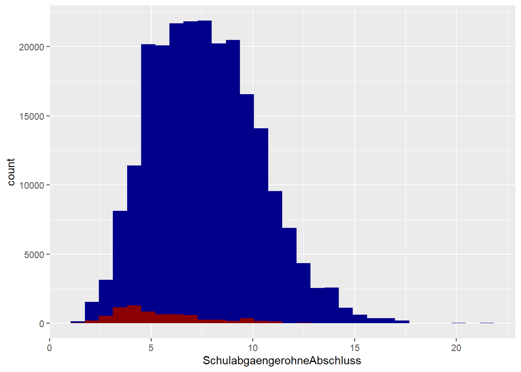

```r
#Adjustmentprüfung
hist_over_SchulabgaengerohneAbschluss <- ggplot() +
  geom_histogram(data = Impdata.imputed[Impdata.imputed[,"G8_jahr"]==0,], aes_string(x = "SchulabgaengerohneAbschluss"), fill ='darkblue')  +
  geom_histogram(data = Impdata.imputed[Impdata.imputed[,"G8_jahr"]==1,], aes_string(x = "SchulabgaengerohneAbschluss"), fill ='darkred')

hist_over_SchulabgaengerohneAbschluss_adj <- ggplot() +
  geom_histogram(data = Impdata.imputed[Impdata.imputed[,"G8_jahr"]==0,], aes_string(x = "SchulabgaengerohneAbschluss_adj"), fill ='darkblue')  +
  geom_histogram(data = Impdata.imputed[Impdata.imputed[,"G8_jahr"]==1,], aes_string(x = "SchulabgaengerohneAbschluss_adj"), fill ='darkred')

hist_over_SchulabgaengerohneAbschluss
```

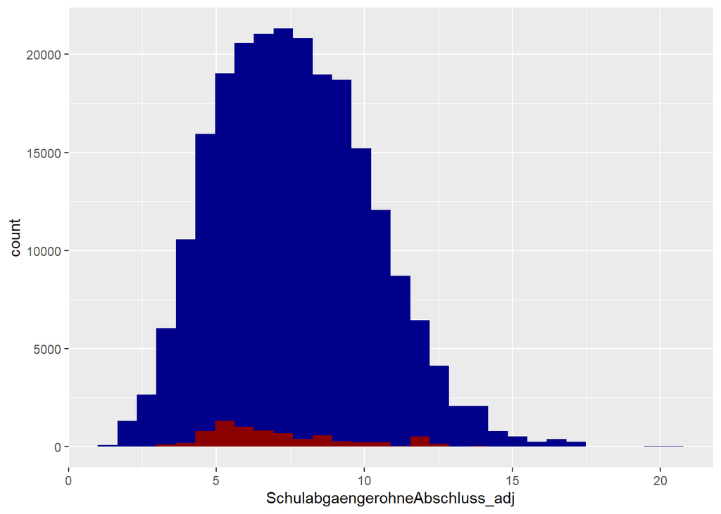

```r
hist_over_SchulabgaengerohneAbschluss_adj
```

- Erstellen von Hilfsvariablen um Änderung der Messung von SV Beschäftigten am Wohnort festzustellen
- Adjustment der SV Beschäftigte Indikatoren anhand von Änderungseffekten (Koeffizient des Effekts vor 2013 wird vom Indikator abgezogen)
- Check des Adjustments durch Histogramm

```r
Impdata.imputed <- Impdata.imputed %>% mutate(Messaenderung_Besch = ifelse(Jahr < 2013, 1, 0))

hist_over_vor_messanpassung <- ggplot() +
  geom_histogram(data = Impdata.imputed[Impdata.imputed[,"Jahr"]<2013,], aes_string(x = "BeschaeftigteohneAbschluss"), fill ='darkblue')  +
  geom_histogram(data = Impdata.imputed[Impdata.imputed[,"Jahr"]>=2013,], aes_string(x = "BeschaeftigteohneAbschluss"), fill ='darkred')


Messaenderung <- function(data,outcome_name){
  mydata   <- data %>%
    select(Gemeindekennziffer, Jahr, Messaenderung_Besch, "Outcome"=paste(outcome_name)) %>%
    mutate(MEAN=mean(Outcome , na.rm=T)) %>% ungroup()

  mymodell_Messaenderung <- lm(Outcome ~
                  I(Jahr*Jahr*MEAN) + I(Jahr*MEAN) + Messaenderung_Besch, data = mydata  , na.action="na.exclude")

  print(mymodell_Messaenderung)
  summary(mymodell_Messaenderung)$coefficients[4,1]
    mydata <- mydata %>%
      mutate(coef = summary(mymodell_Messaenderung)$coefficients[4,1]) %>%
      mutate(Outcome = ifelse(Messaenderung_Besch == 1, Outcome - coef, Outcome)) %>%
      pull(Outcome)
}

Impdata.imputed <- Impdata.imputed %>%
  mutate(BeschaeftigteohneAbschluss_adj = Messaenderung(.,"BeschaeftigteohneAbschluss"),
         BeschaeftigtemitakadAbschluss_adj = Messaenderung(.,"BeschaeftigtemitakadAbschluss"))
```

```
##
## Call:
## lm(formula = Outcome ~ I(Jahr * Jahr * MEAN) + I(Jahr * MEAN) +
##     Messaenderung_Besch, data = mydata, na.action = "na.exclude")
##
## Coefficients:
##           (Intercept)  I(Jahr * Jahr * MEAN)         I(Jahr * MEAN)
##             5.171e+04              9.817e-04             -3.958e+00
##   Messaenderung_Besch
##             1.668e+00
##
##
## Call:
## lm(formula = Outcome ~ I(Jahr * Jahr * MEAN) + I(Jahr * MEAN) +
##     Messaenderung_Besch, data = mydata, na.action = "na.exclude")
##
## Coefficients:
##           (Intercept)  I(Jahr * Jahr * MEAN)         I(Jahr * MEAN)
##             2.549e+04              7.003e-04             -2.786e+00
##   Messaenderung_Besch
##             1.455e+00
```

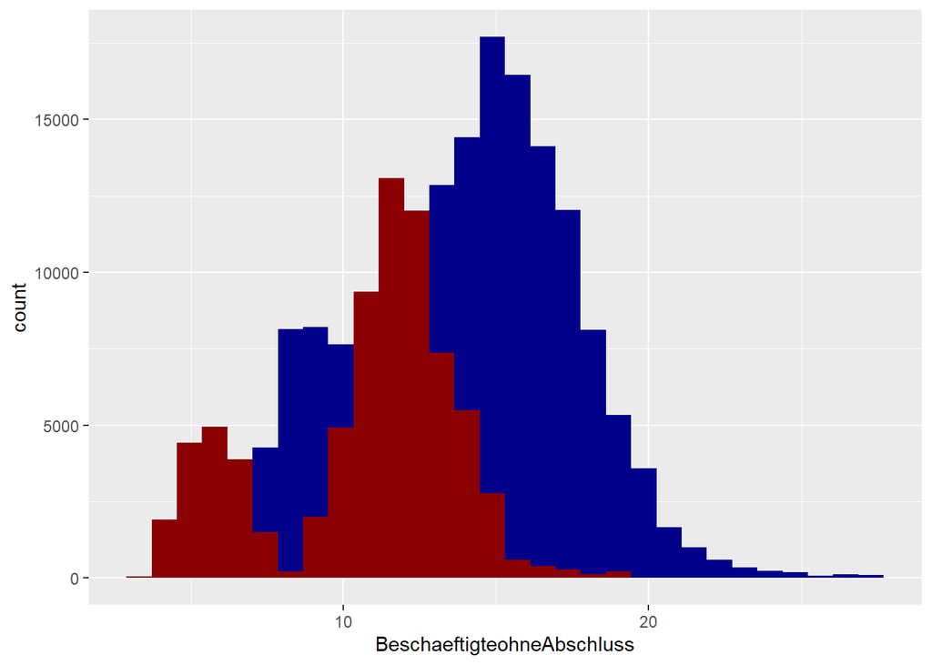

```r
#Adjustmentprüfung
hist_over_nach_messanpassung <- ggplot() +
  geom_histogram(data = Impdata.imputed[Impdata.imputed[,"Jahr"]<2013,], aes_string(x = "BeschaeftigteohneAbschluss_adj"), fill ='darkblue')  +
  geom_histogram(data = Impdata.imputed[Impdata.imputed[,"Jahr"]>=2013,], aes_string(x = "BeschaeftigteohneAbschluss_adj"), fill ='darkred')

hist_over_vor_messanpassung
```

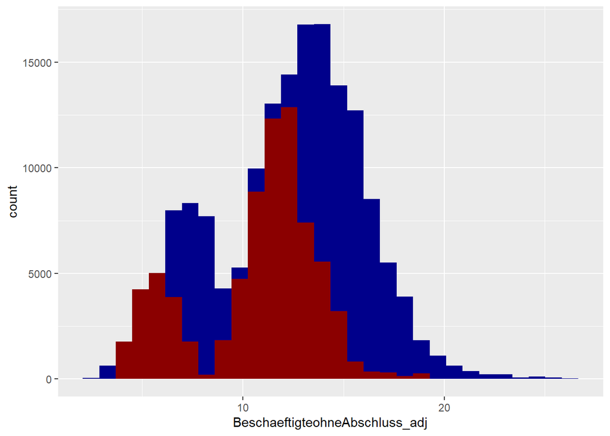

```r
hist_over_nach_messanpassung
```

- Erstellen von Hilfsvariablen zur Identifikation von Ost und West Kreisen
- Adjustment des Beschäftigte ohne Abschluss Indikatoren anhand von Ost-West-Unterschieden (Koeffizient des Effekts wird vom Indikator abgezogen)
- Check des Adjustments durch Histogramm

```r
Impdata.imputed <- Impdata.imputed %>% mutate(OW = ifelse(Kreis < 11000, 0, 1))

# mydata   <- Impdata.imputed %>%
#    select(Gemeindekennziffer, Jahr, OW, BeschaeftigteohneAbschluss_adj) %>%
#    mutate(Jahr_Dummy = as.factor(Jahr)) %>% ungroup()
#
#    mymodell_ow <- lm(BeschaeftigteohneAbschluss_adj ~ Jahr_Dummy + relevel(Jahr_Dummy, ref = "2012") * OW, data = #mydata, na.action="na.exclude")
#
#    summary(mymodell_ow)

#Adjustmentprüfung
hist_over_westost <- ggplot() +
  geom_histogram(data = Impdata.imputed[Impdata.imputed[,"Kreis"]<11000,], aes_string(x = "BeschaeftigteohneAbschluss_adj"), fill ='darkblue')  +
  geom_histogram(data = Impdata.imputed[Impdata.imputed[,"Kreis"]>=11000,], aes_string(x = "BeschaeftigteohneAbschluss_adj"), fill ='darkred')


OW <- function(data,outcome_name){
  mydata   <- data %>%
    select(Gemeindekennziffer, Jahr, OW, "Outcome"=paste(outcome_name)) %>%
    mutate(Jahr_Dummy = as.factor(Jahr)) %>% ungroup()

    mymodell_ow <- lm(Outcome ~ Jahr_Dummy + relevel(Jahr_Dummy, ref = "2012") * OW, data = mydata, na.action="na.exclude")

  print(mymodell_ow)
  summary(mymodell_ow)$coefficients[23,1]
    mydata %>% mutate(coef = summary(mymodell_ow)$coefficients[23,1]) %>%
      mutate(Outcome = ifelse(OW == 1, Outcome - coef, Outcome)) %>%
      pull(Outcome)
}

Impdata.imputed <- Impdata.imputed %>%
  mutate(BeschaeftigteohneAbschluss_adj = OW(.,"BeschaeftigteohneAbschluss_adj"))
```

```
##
## Call:
## lm(formula = Outcome ~ Jahr_Dummy + relevel(Jahr_Dummy, ref = "2012") *
##     OW, data = mydata, na.action = "na.exclude")
##
## Coefficients:
##                              (Intercept)
##                                 16.01960
##                           Jahr_Dummy1999
##                                 -0.30620
##                           Jahr_Dummy2000
##                                 -0.61271
##                           Jahr_Dummy2001
##                                 -0.91953
##                           Jahr_Dummy2002
##                                 -0.92445
##                           Jahr_Dummy2003
##                                 -1.46633
##                           Jahr_Dummy2004
##                                 -1.88821
##                           Jahr_Dummy2005
##                                 -2.26817
##                           Jahr_Dummy2006
##                                 -2.62342
##                           Jahr_Dummy2007
##                                 -2.82918
##                           Jahr_Dummy2008
##                                 -2.91360
##                           Jahr_Dummy2009
##                                 -3.11533
##                           Jahr_Dummy2010
##                                 -3.51668
##                           Jahr_Dummy2011
##                                 -3.91873
##                           Jahr_Dummy2012
##                                 -4.95550
##                           Jahr_Dummy2013
##                                 -4.32403
##                           Jahr_Dummy2014
##                                 -4.38260
```

[output cut: 81 more lines]

```
##                                  0.06119
## relevel(Jahr_Dummy, ref = "2012")2013:OW
##                                 -0.06118
## relevel(Jahr_Dummy, ref = "2012")2014:OW
##                                 -0.05695
## relevel(Jahr_Dummy, ref = "2012")2015:OW
##                                  0.20947
## relevel(Jahr_Dummy, ref = "2012")2016:OW
##                                  0.42409
## relevel(Jahr_Dummy, ref = "2012")2017:OW
##                                  0.59302
## relevel(Jahr_Dummy, ref = "2012")2018:OW
##                                  0.79041
## relevel(Jahr_Dummy, ref = "2012")2019:OW
##                                  1.01887
```

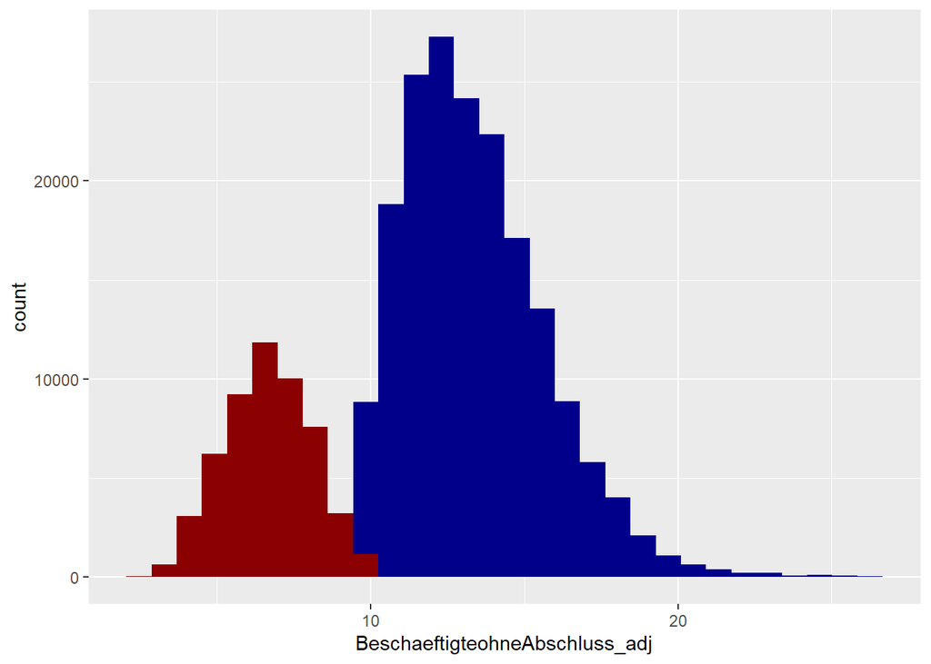

```r
hist_over_westost_adj <- ggplot() +
  geom_histogram(data = Impdata.imputed[Impdata.imputed[,"Kreis"]<11000,], aes_string(x = "BeschaeftigteohneAbschluss_adj"), fill ='darkblue')  +
  geom_histogram(data = Impdata.imputed[Impdata.imputed[,"Kreis"]>=11000,], aes_string(x = "BeschaeftigteohneAbschluss_adj"), fill ='darkred')

hist_over_westost
```

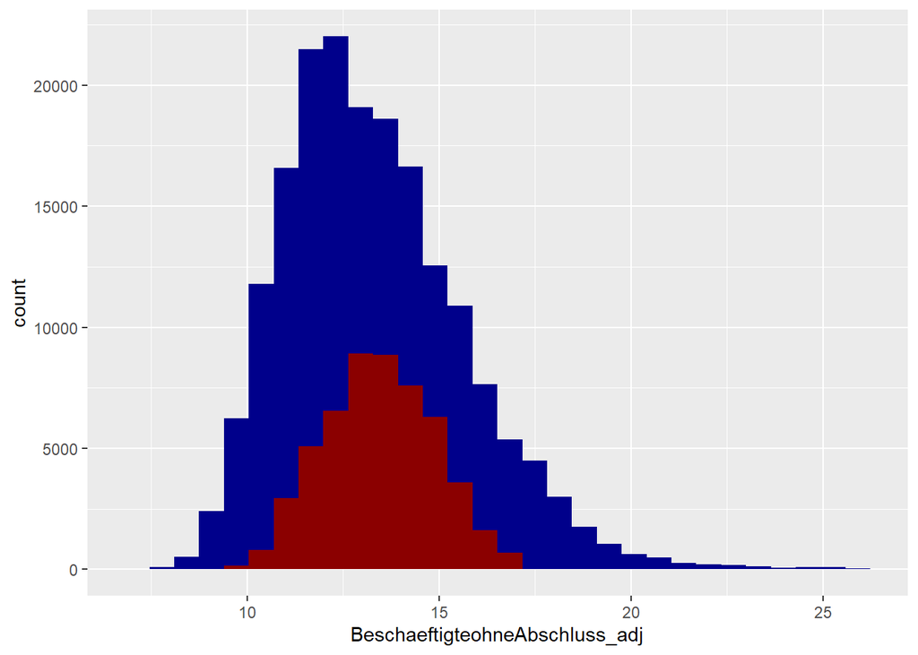

```r
hist_over_westost_adj
```

- Anpassung von Einkommensteuer, Haushaltsankommen und Bruttoverdienst an Verbraucherpreisindex
- Logarithmierung von Einkommensteuer, Haushaltseinkommen, Bruttoverdienst

```r
Verbraucherpreisindex <- data.frame(Jahr = c(1998, 1999, 2000, 2001, 2002, 2003, 2004, 2005, 2006, 2007, 2008, 2009, 2010, 2011, 2012, 2013, 2014, 2015, 2016, 2017, 2018, 2019, 2020),
                                    VBindex =  c(78.3, 78.8 , 79.9, 81.5, 82.6, 83.5, 84.9, 86.2, 87.6, 89.6, 91.9, 92.2, 93.2, 95.2, 97.1, 98.5, 99.5, 100, 100.5, 102, 103.8, 105.3, 105.8))

Impdata.imputed <- Impdata.imputed %>% left_join(Verbraucherpreisindex, by = "Jahr")

Impdata.imputed <- Impdata.imputed %>% mutate(Einkommensteuer = Einkommensteuer / VBindex * 100, Haushaltseinkommen = Haushaltseinkommen / VBindex * 100, Bruttoverdienst = Bruttoverdienst / VBindex * 100)


Impdata.imputed <- Impdata.imputed %>% mutate(Einkommensteuer_ln = ifelse(Einkommensteuer==0, 0.75, log(Einkommensteuer)))

Impdata.imputed <- Impdata.imputed %>% mutate(Haushaltseinkommen_ln = log(Haushaltseinkommen))

Impdata.imputed <- Impdata.imputed %>% mutate(Bruttoverdienst_ln = log(Bruttoverdienst))
```

- Ausschreiben des aktuellen Datensatzes als STATA- und RDS-File

```r
# Stata-Datensatz rausschreiben
stata_data <- Impdata.imputed %>%
  mutate(SchulabgmitAbi_adj = SchulabgaengermitHochschulreife_adj, BeschaeftigteohneAbschlussadj = BeschaeftigteohneAbschluss_adj, BeschaeftigtemitakadAbschlussadj = BeschaeftigtemitakadAbschluss_adj) %>%
  select(-SchulabgaengermitHochschulreife_adj,
         -BeschaeftigteohneAbschluss_adj,
         -BeschaeftigtemitakadAbschluss_adj)
write_dta(stata_data, paste0("Outfiles/2022/Stata/Impdata_check_2019.dta"))
rm(stata_data)

# RDS-Datensatz rausschreiben
write_rds(Impdata.imputed, paste0("Outfiles/2022/Impdata_check.rds"))
```

## IV. Faktorenanalyse (Hauptkomponentenanalyse) inklusive Generierung der Faktorscores

- Herunterbrechen der Indikatoren in die einzelnen Teildimensonen

# Faktorenanalyse basierend auf Hauptkomponentenanalyse für jede der drei Subscalen

- PCA für jede Dimension

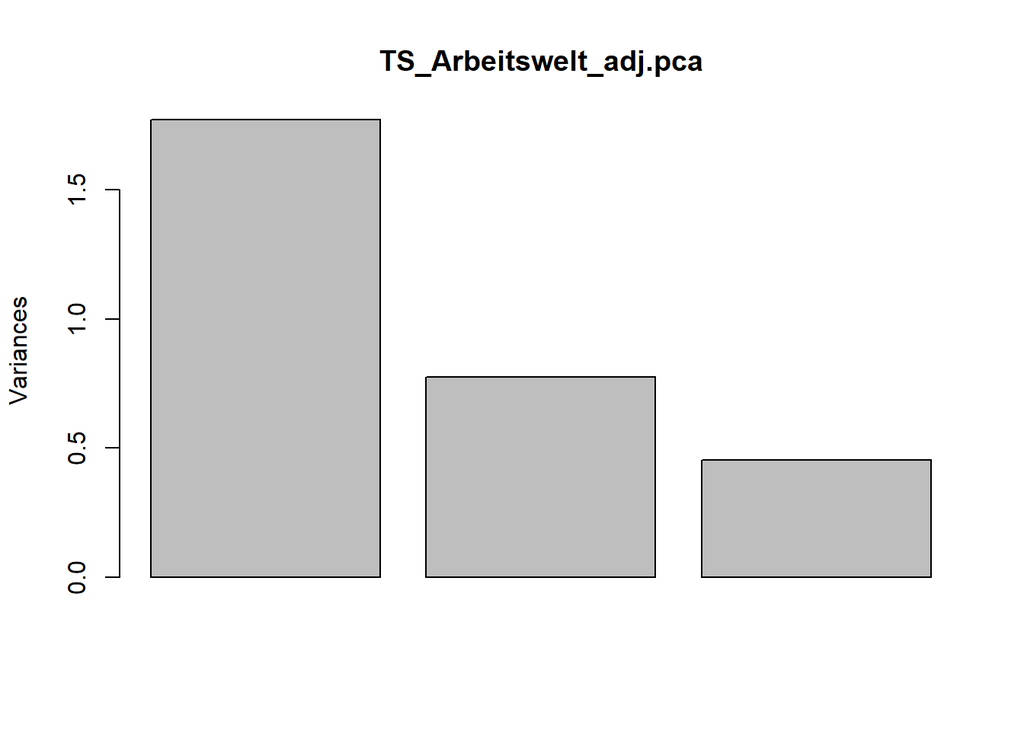

```
## Standard deviations (1, .., p=3):
## [1] 1.3313273 0.8795260 0.6737964
##
## Rotation (n x k) = (3 x 1):
##                            PC1
## Beschaeftigtenquote  0.4806013
## Arbeitslosigkeit    -0.6315052
## Bruttoverdienst_ln   0.6084600
```

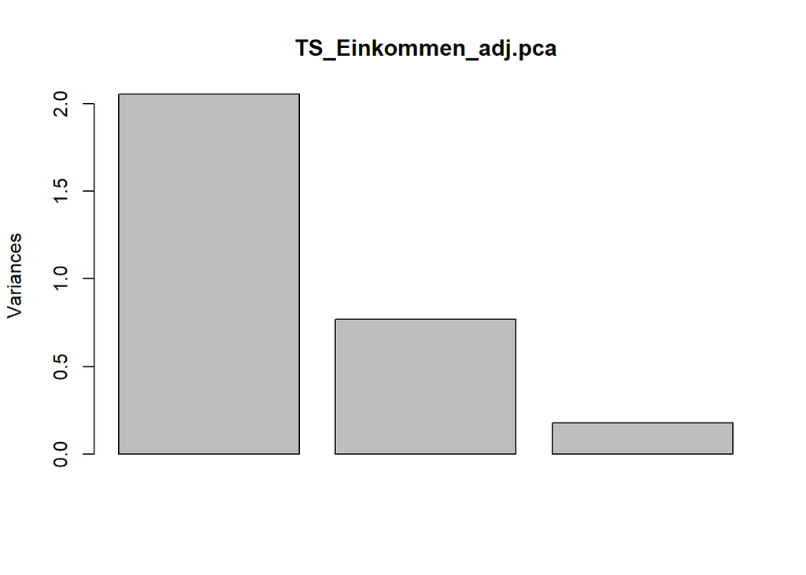

```
## Standard deviations (1, .., p=3):
## [1] 1.4337226 0.8769340 0.4188394
##
## Rotation (n x k) = (3 x 1):
##                              PC1
## Einkommensteuer_ln    -0.6379573
## Haushaltseinkommen_ln -0.6428335
## Schuldnerquote         0.4239995
```

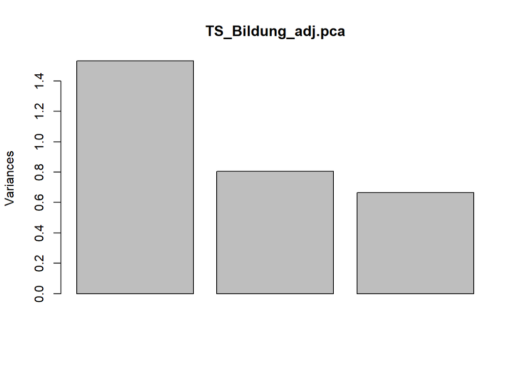

```
## Standard deviations (1, .., p=3):
## [1] 1.2377441 0.8968240 0.8146757
##
## Rotation (n x k) = (3 x 1):
##                                          PC1
## BeschaeftigtemitakadAbschluss_adj  0.5981917
## BeschaeftigteohneAbschluss_adj    -0.6099935
## SchulabgaengerohneAbschluss_adj   -0.5196870
```

# Nun wird die Generierung der Faktorscores vorbereitet.

- Erstellen einer Tablle zu den einzelnen Faktorladungen (wie Faktoranalyse-RMD)
- Prediction des GISD-Scores
- Polen der Dimensionen
- Normalisierung des Scores für jedes Jahr
- Ausschreiben des aktuellen Datensatzes

```
##  TS_Arbeitswelt_adj TS_Einkommen_adj   TS_Bildung_adj
##  Min.   :-5.60186   Min.   :-5.96935   Min.   :-5.3323
##  1st Qu.:-0.86159   1st Qu.:-0.90664   1st Qu.:-1.0461
##  Median :-0.00057   Median :-0.02075   Median :-0.0996
##  Mean   :-0.09252   Mean   : 0.08350   Mean   :-0.1351
##  3rd Qu.: 0.81946   3rd Qu.: 0.89530   3rd Qu.: 0.6869
##  Max.   : 4.71039   Max.   : 7.15459   Max.   : 7.1725
```

```
##                    Arbeitslosigkeit TS_Arbeitswelt_adj TS_Einkommen_adj
## Arbeitslosigkeit          1.0000000         -0.8432757        0.8349946
## TS_Arbeitswelt_adj       -0.8432757          1.0000000       -0.8621604
## TS_Einkommen_adj          0.8349946         -0.8621604        1.0000000
## TS_Bildung_adj           -0.3667822          0.4815159       -0.5286493
##                    TS_Bildung_adj
## Arbeitslosigkeit       -0.3667822
## TS_Arbeitswelt_adj      0.4815159
## TS_Einkommen_adj       -0.5286493
## TS_Bildung_adj          1.0000000
```

```
##                    Arbeitslosigkeit TS_Arbeitswelt_adj TS_Einkommen_adj
## Arbeitslosigkeit          1.0000000          0.8432757        0.8349946
## TS_Arbeitswelt_adj        0.8432757          1.0000000        0.8621604
## TS_Einkommen_adj          0.8349946          0.8621604        1.0000000
## TS_Bildung_adj            0.3667822          0.4815159        0.5286493
##                    TS_Bildung_adj
## Arbeitslosigkeit        0.3667822
## TS_Arbeitswelt_adj      0.4815159
## TS_Einkommen_adj        0.5286493
## TS_Bildung_adj          1.0000000
```

```
##                            Variable      Dimension            Anteil
## 1               Beschaeftigtenquote    Arbeitswelt 0.230977643666659
## 2                  Arbeitslosigkeit    Arbeitswelt 0.398798775705837
## 3                Bruttoverdienst_ln    Arbeitswelt 0.370223580627503
## 4                Einkommensteuer_ln      Einkommen 0.406989491404615
## 5             Haushaltseinkommen_ln      Einkommen 0.413234939563626
## 6                    Schuldnerquote      Einkommen 0.179775569031759
## 7 BeschaeftigtemitakadAbschluss_adj Bildung (adj.) 0.357833338534548
## 8    BeschaeftigteohneAbschluss_adj Bildung (adj.) 0.372092114824685
## 9   SchulabgaengerohneAbschluss_adj Bildung (adj.) 0.270074546640767
##                Score GISD Proportion
## 1   0.48060133548156 GISD       23.1
## 2 -0.631505166808505 GISD       39.9
## 3  0.608460007418321 GISD       37.0
## 4 -0.637957280234825 GISD       40.7
## 5 -0.642833523988619 GISD       41.3
## 6   0.42399949178243 GISD       18.0
## 7  0.598191723893392 GISD       35.8
## 8 -0.609993536707304 GISD       37.2
## 9 -0.519686969858555 GISD       27.0
```

```
##  TS_Arbeitswelt_adj TS_Einkommen_adj TS_Bildung_adj     GISD_Score
##  Min.   :0.0000     Min.   :0.0000   Min.   :0.0000   Min.   :0.0000
##  1st Qu.:0.3773     1st Qu.:0.3858   1st Qu.:0.5187   1st Qu.:0.4740
##  Median :0.4568     Median :0.4533   Median :0.5815   Median :0.5700
##  Mean   :0.4657     Mean   :0.4612   Mean   :0.5844   Mean   :0.5695
##  3rd Qu.:0.5403     3rd Qu.:0.5231   3rd Qu.:0.6572   3rd Qu.:0.6624
##  Max.   :1.0000     Max.   :1.0000   Max.   :1.0000   Max.   :1.0000
```

```
## tibble [237,534 x 4] (S3: tbl_df/tbl/data.frame)
##  $ TS_Arbeitswelt_adj: num [1:237534] 0.643 0.588 0.609 0.598 0.604 ...
##  $ TS_Einkommen_adj  : num [1:237534] 0.666 0.59 0.623 0.666 0.585 ...
##  $ TS_Bildung_adj    : num [1:237534] 0.761 0.705 0.75 0.881 0.758 ...
##  $ GISD_Score        : num [1:237534] 0.773 0.646 0.713 0.824 0.69 ...
```

## V. Datenexport - Erstellung der Datensätze

- Ausschreibeen des GISD-Scores in den Outfiles-Ordner (für Bund und Bundesland; jedweils als .CSV oder STATA-File)

```
## [1] "Level: Name der Gemeinde Label: Gemeinde"
```

[output not shown]

```
## [1] "Level: Name des Kreises Label: Kreis"
```

```
## [1] "Level: Name des Gemeindeverbands Label: Gemeindeverband"
```

```
## [1] "Level: Raumordnungsregion Label: Raumordnungsregion"
```

```
## [1] "Level: NUTS2 Name Label: NUTS2"
```

## VI. Datensätze für PLZ generieren

- Ausschreiben des GISD-Scores nach Postleitzahl